[figure not shown]

# ESTADISTICA PARA EL SECTOR PUBLICO

- Profesor: [Dr. José Manuel Magallanes, Ph.D.](http://www.pucp.edu.pe/profesor/jose-manuel-magallanes/)
  - Profesor del Departamento de Ciencias Sociales, Sección de Ciencia Política y Gobierno.
  - [Oficina 105](https://goo.gl/maps/xuGeG6o9di1i1y5m6) - Edificio CISEPA / ECONOMIA / CCSS
  - Telefono: (51) 1 - 6262000 anexo 4302
  - Correo Electrónico: jmagallanes@pucp.edu.pe

# Sesión 2: Exploración Numérica

El link tiene datos de accidentes ocurridos en las empresas mineras del 2000 al 2006:

```r
link2='https://docs.google.com/spreadsheets/d/e/2PACX-1vTgDnZeJUe5Qdn-Il3Ob1u630GIYyxf5nomPu3oqrb5L31vUYCHsrtA0_tl2gEQ82mOI7-l1B9TtyZo/pub?gid=753961441&single=true&output=csv'

mineria=read.csv(link2, stringsAsFactors = F)

# que tenemos
str(mineria)
```

```
## 'data.frame':    33 obs. of  4 variables:
##  $ EMPRESA    : chr  "Ananea" "Antamina" "Ares" "Argentum" ...
##  $ Responsable: chr  "Contrata" "Empresa" "Empresa" "Contrata" ...
##  $ Tama       : chr  "Pequeña" "Grande" "Mediana" "Mediana" ...
##  $ accidentes : int  20 5 10 6 5 19 5 23 6 16 ...
```

### Parte 1. Exploración Gráfica

**NOTA**: Las variables numéricas no requieren tablas de frecuencia para ser exploradas.

- El grafico inicial a usar es el histograma:

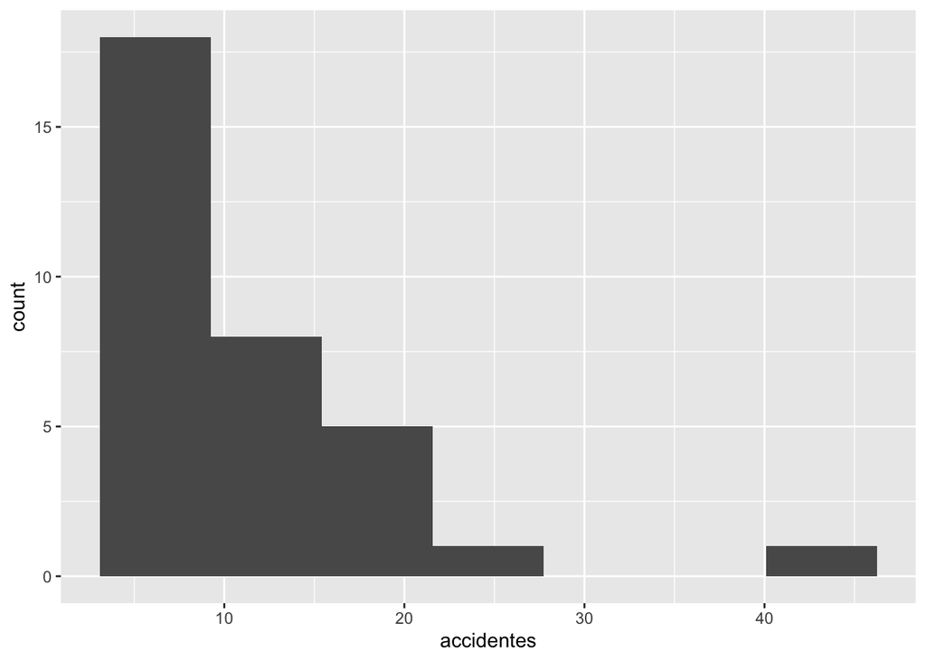

```r
library(ggplot2)
base1=ggplot(mineria,aes(x=accidentes))
histNum= base1 + geom_histogram(bins=7)
histNum
```

La exploración numérica nos debe sugerir:

- Si la media es representativo o no.
- Si hay asimetría, y hacia donde se concentran los datos.
- Si hay valores atípicos.

Del gráfico podemos decir que, como no es simétrico, informar la **media** de accidentes no será muy representativa (la **mediana** será la mejor opción); por otro lado, como la asimetría nos muestra que los accidentes son en su mayoría pocos. Hay un numero de accidentes que se aleja hacia valores altos, pero no estamos seguros si está tan lejos del ‘centro’ para ser atípico.

Los atípicos se ven claramente en un boxplot:

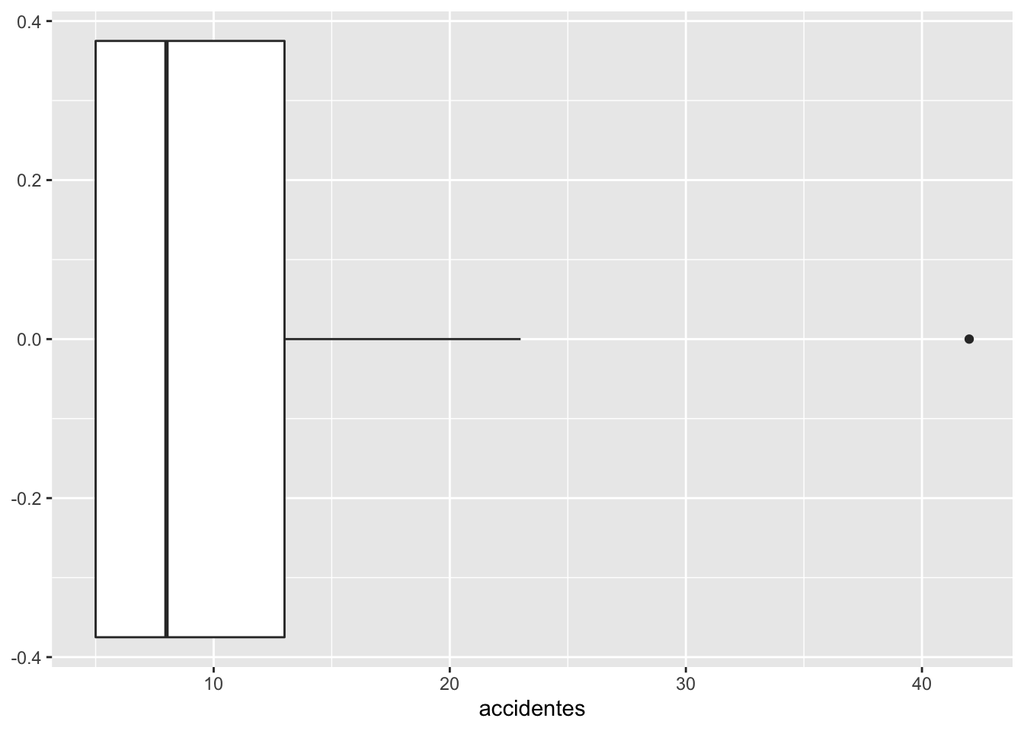

```r
base2=ggplot(mineria,aes(y=accidentes))
box=base2 + geom_boxplot() + coord_flip()

box
```

El punto a la derecha confirma que hay atípicos.

Para ser más preciso en nuestra exploración, debemos calcular diversos indicadores.

### Parte 2. Exploración con Estadígrafos

Los estadigrafos aparecen rapidamente así:

```r
summary(mineria$accidentes)
```

```
##    Min. 1st Qu.  Median    Mean 3rd Qu.    Max.
##    5.00    5.00    8.00   10.76   13.00   42.00
```

Podriamos graficarlos en el boxplot:

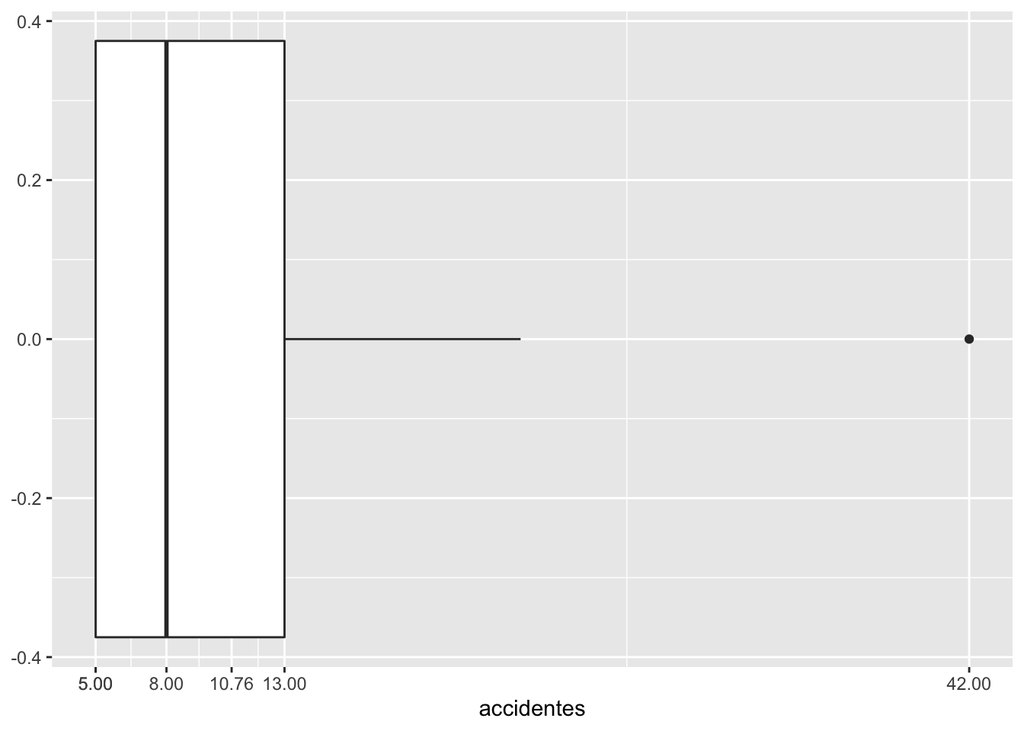

```r
library(ggplot2)

estadigrafos=round(as.vector(summary(mineria$accidentes)),2)

box + scale_y_continuous(breaks = estadigrafos)
```

¿Te das cuenta por que hay asimetría?

Si la media es mayor que la mediana la asimetría tiende a ser positiva (cola a la derecha). Hay tendencia a la asimetría negativa (cola a la izquierda) cuando la mediana es mayor que la media. Aquí se nota claramente que hay asimetría, pero podemos confirmarla calculando el coeficiente respectivo:

```r
library(DescTools)
Skew(mineria$accidentes,conf.level = 0.05)
```

```
##     skew   lwr.ci   upr.ci
## 2.251112 2.590235 2.656866
```

La distancia intercuartilica es importante saberla:

```r
IQR(mineria$accidentes)
```

```
## [1] 8
```

Es decir, entre el primer y tercer cuartil hay sólo 8 valores; asi, el 50% de los valores centrales varian en 8 valores. Así, podemos proponer que un atípico es aquel que está a una distancia lejana de estos valores centrales. Este umbral, tradicionalmente se calcula así:

```r
# cuartil tres
q3=as.numeric(summary(mineria$accidentes)[5])

# calculando umbral (distancia del q3)
umbral= q3+1.5*IQR(mineria$accidentes)
umbral
```

```
## [1] 25
```

Osea, en teoria, todo valor mayor que 25 será considerado un atípico:

```r
mineria[mineria$accidentes>umbral,]
```

```
##    EMPRESA Responsable   Tama accidentes
## 31  Volcan    Contrata Grande         42
```

Los accidentes pueden ser representados en el Gini:

```r
Gini(mineria$accidentes,conf.level=0.95)
```

```
##      gini    lwr.ci    upr.ci
## 0.3362676 0.2758900 0.4403345
```

Si el Gini es 0, todas las empresas causan la misma cantidad de accidentes; si fuera 1, una sola empresa causa todos los accidentes.

Normalmente al Gini le acompaña la curva de Lorenz:

```r
library(gglorenz) # instalar
```

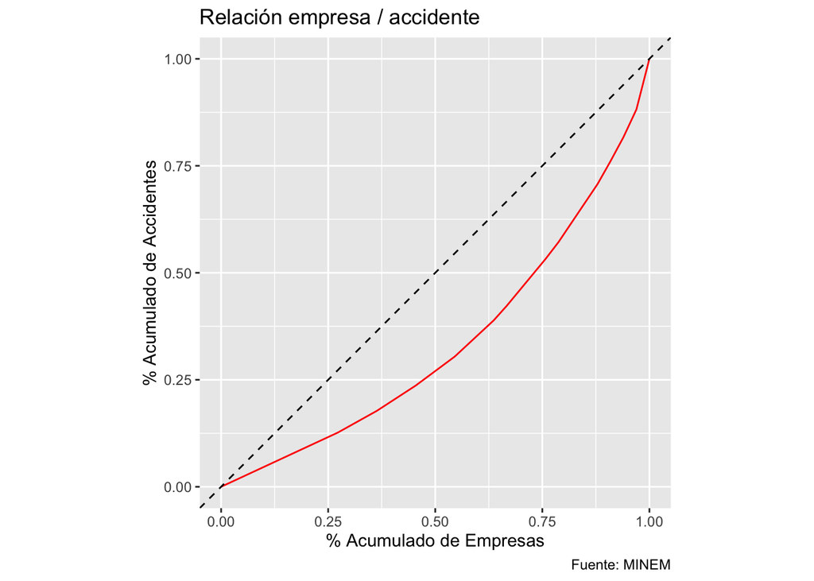

```r
base1 + gglorenz::stat_lorenz(color='red') +
    geom_abline(linetype = "dashed") + coord_fixed() +
    labs(x = "% Acumulado de Empresas",
         y = "% Acumulado de Accidentes",
         title = "Relación empresa / accidente",
         caption = "Fuente: MINEM")
```

Si la curva se acerca a la diagonal, hay igualdad de distribución: cada empresa contribuye con la misma cantidad de accidentes (Gini = 0).

Volver al [INDICE DEL CURSO](https://politicaygobiernopucp.github.io/EstadisticaSectorPublico/)